# UC00191_Urban_Design_And_Physical_Activity

Urban Design and Physical Activity

Author: Nidhi Kanchepalle

Level: Intermediate

Skills: Python, Exploratory Data Analysis, Data Visualisation

Scenario

This use case explores how urban design influences physical activity across Melbourne by analysing open datasets on pedestrian counts, footpaths, playgrounds, residential profiles, building footprints, and suburb boundaries. The objective is to uncover spatial and temporal patterns in pedestrian movement and examine how various elements of the built environment contribute to walking behaviour. The pedestrian counts data spans from 2023 to 2025, providing a recent view of foot traffic trends across the city. By integrating geospatial and demographic data—including building footprints that reveal density, height, and structure types—the analysis aims to identify suburbs that promote higher levels of physical activity and understand the role of infrastructure—such as well-connected footpaths, access to recreational areas, and population distribution—in shaping these trends. The insights derived from this study can help urban planners make informed, evidence-based decisions to design healthier, more walkable neighbourhoods that encourage active lifestyles.

What This Use Case Will Teach You

At the end of this use case, you will be able to:

- Learn how to load data using APIs
- Handle missing values and prepare the data for meaningful analysis
- Use grouping, filtering, and aggregation techniques to uncover patterns and trends
- Perform spatial joins and analyse geospatial data using GeoPandas
- Visualise temporal and spatial trends using appropriate charts and maps
- Identify correlations between infrastructure features and pedestrian activity
- Generate actionable insights to inform urban planning decisions

Background / Introduction

Urban planning plays a crucial role in shaping how people interact with their surroundings, especially when it comes to promoting active lifestyles. Walkable neighbourhoods with accessible footpaths, green spaces, and recreational areas are more likely to encourage residents to engage in physical activity. As cities grow, there is a growing need for data-driven approaches to understand how urban design influences movement patterns and community well-being.

This use case aims to explore the relationship between urban infrastructure and physical activity levels, using pedestrian count data. By integrating multiple open datasets—such as pedestrian count data, footpath networks, playground locations, building footprints, suburb boundaries, and demographic profiles—we aim to uncover trends and spatial patterns that highlight how the built environment impacts walking behaviour.

Through this analysis, urban planners and decision-makers can gain insights into which areas support active lifestyles and where improvements in infrastructure could have the most impact. The ultimate goal is to use data to inform more effective urban design strategies that prioritise health, accessibility, and sustainability across Melbourne's suburbs.

```python
import pandas as pd
from io import StringIO
from shapely.geometry import Point
import requests
import seaborn as sns
import matplotlib.pyplot as plt
import geopandas as gpd
import contextily as ctx
from io import BytesIO
import urllib3
urllib3.disable_warnings(urllib3.exceptions.InsecureRequestWarning)
import folium
from folium.plugins import HeatMap
from sklearn.cluster import KMeans
import numpy as np
from shapely.geometry import Point
from datetime import datetime
from sklearn.preprocessing import StandardScaler
from sklearn.cluster import KMeans
import statsmodels.api as sm
import statsmodels.formula.api as smf
from sklearn.ensemble import IsolationForest
import warnings
warnings.filterwarnings("ignore", category=FutureWarning, module="pandas")
import re
```

## Importing Data Through API

```python
with open("API_Key.txt", "r", encoding="utf-8-sig") as f:
    API_KEY = f.read().strip()

# Define API data fetching function
def API_upload(dataset_key):
    base_url = 'https://data.melbourne.vic.gov.au/api/explore/v2.1/catalog/datasets/'
    format = 'csv'
    full_url = f'{base_url}{dataset_key}/exports/{format}'

    params = {
        'select': '*',
        'timezone': 'UTC',
        'lang': 'en',
        'limit': '-1'
    }

    headers = {
        'X-App-Token': API_KEY
    }

    response = requests.get(full_url, params=params, headers=headers)
    if response.status_code == 200:
        content = response.content.decode('utf-8')
        df = pd.read_csv(StringIO(content), delimiter=';')
        df['SOURCE_DATASET'] = dataset_key
        return df
    else:
        print(f"Error fetching data from {full_url}: {response.status_code}")
        return pd.DataFrame()

data_sets = {
    "pedestrian_counts": ['pedestrian-counting-system-monthly-counts-per-hour'],
    "building_footprints": ['2023-building-footprints'],
    "playgrounds": ['playgrounds'],
    "footpaths": ['footpaths'],
    "resident_profiles": ['residents-profiles-by-clue-small-area']
}

pedestrian_counts_df = pd.concat([API_upload(ds) for ds in data_sets["pedestrian_counts"]], ignore_index=True)
building_footprints_df = pd.concat([API_upload(ds) for ds in data_sets["building_footprints"]], ignore_index=True)
playgrounds_df = pd.concat([API_upload(ds) for ds in data_sets["playgrounds"]], ignore_index=True)
footpaths_df = pd.concat([API_upload(ds) for ds in data_sets["footpaths"]], ignore_index=True)
resident_profiles_df = pd.concat([API_upload(ds) for ds in data_sets["resident_profiles"]], ignore_index=True)
```

```python
url = "https://opendata.maps.vic.gov.au/geoserver/wfs?service=WFS&version=2.0.0&request=GetFeature&typeName=open-data-platform:locality_polygon&outputFormat=application/json&srsName=EPSG:4326&count=5000"

response = requests.get(url, verify=False)

localities_df = gpd.read_file(BytesIO(response.content))
```

## Inspecting Data

The pedestrian counts dataset contains hourly foot traffic data recorded by sensors installed at various locations across Melbourne. Each entry includes the date, hour, sensor location, counts in both directions, and total pedestrian activity. This data is useful for identifying spatial and temporal trends in pedestrian movement, such as peak walking hours or high-traffic areas.

```python
print("\nPedestrian Count Dataset Shape:", pedestrian_counts_df.shape)
print(pedestrian_counts_df.head())
```

```
Pedestrian Count Dataset Shape: (1408003, 10)
              id  location_id sensing_date  hourday  direction_1  direction_2  \
0  1351920240411          135   2024-04-11       19          208          244
1  1351520241107          135   2024-11-07       15          436          388
2  1351920250107          135   2025-01-07       19          214          289
3   107320250130          107   2025-01-30        3            2            0
4  1181920240506          118   2024-05-06       19            2            5

   pedestriancount sensor_name                    location  \
0              452   Spen161_T   -37.8172861, 144.95319102
1              824   Spen161_T   -37.8172861, 144.95319102
2              503   Spen161_T   -37.8172861, 144.95319102
3                2   280Will_T  -37.81246271, 144.95690188
4                7   Fli114C_T  -37.81632783, 144.97090512

                                      SOURCE_DATASET
0  pedestrian-counting-system-monthly-counts-per-...
1  pedestrian-counting-system-monthly-counts-per-...
2  pedestrian-counting-system-monthly-counts-per-...
3  pedestrian-counting-system-monthly-counts-per-...
4  pedestrian-counting-system-monthly-counts-per-...
```

```python
start_date = pedestrian_counts_df['sensing_date'].min()
end_date = pedestrian_counts_df['sensing_date'].max()
print(start_date)
print(end_date)
```

```
2023-09-15
2025-09-14
```

The building footprints dataset contains spatial and structural details of buildings in Melbourne, including location, roof type, elevation, and building height. It helps in understanding building density and structure, which is useful for analysing how the built environment influences pedestrian movement and urban walkability. In this analysis, it supports a broader understanding of how urban design relates to pedestrian activity within the timeframe of 2023 to 2025.

```python
print("\nBuilding Footprints Dataset Shape:", building_footprints_df.shape)
print(building_footprints_df.head())
```

```
Building Footprints Dataset Shape: (41701, 14)
                              geo_point_2d  \
0   -37.80003539659138, 144.95673941735046
1    -37.84308942324178, 144.9077552355766
2        -37.832043207400005, 144.97921111
3  -37.804107867267376, 144.96814513518797
4  -37.820196601484255, 144.94134917503217

                                           geo_shape  objectid  structure_id  \
0  {"coordinates": [[[144.9567226597, -37.8000656...     20012        815949
1  {"coordinates": [[[144.9078005567, -37.8431403...     20027        804149
2  {"coordinates": [[[144.9792485137, -37.8320547...     20048        815174
3  {"coordinates": [[[144.9682045375, -37.8040924...     20053        811834
4  {"coordinates": [[[144.9412080937, -37.8203657...     20168        806726

```

[output cut: 20 more lines]

The playgrounds dataset provides the locations and features of public playgrounds across Melbourne. It includes geographic coordinates, council reference IDs, and descriptions of playground equipment and facilities. This data helps assess access to recreational spaces and supports analysis of how such amenities relate to pedestrian activity.

```python
print("\nPlaygrounds Dataset Shape:", playgrounds_df.shape)
print(playgrounds_df.head())
```

```
Playgrounds Dataset Shape: (45, 7)
                             geo_point_2d  \
0   -37.80284131718294, 144.9626564799592
1   -37.8095257090171, 144.95471867901864
2  -37.82307176194582, 144.94158310181788
3  -37.79520740161526, 144.96970314493564
4   -37.79616817586979, 144.9267597762389

                                           geo_shape  council_re  \
0  {"coordinates": [[[[144.962585326539, -37.8028...     1450819
1  {"coordinates": [[[[144.95476596702, -37.80945...     1719660
2  {"coordinates": [[[[144.941286023475, -37.8230...     1590516
3  {"coordinates": [[[[144.969754004322, -37.7951...     1603370
4  {"coordinates": [[[[144.926747982283, -37.7961...     1554261

                                            features location_d  \
0  Swings, spinners, double slide, public toilet,...        NaN
1  Sandpit with diggers, spiral slide, swings, sa...        NaN
2  Bells, Musical Wall, Sand pit, Swing, Carousel...        NaN
3                                    1 x 5 way swing        NaN
4                                                NaN        NaN

                           name SOURCE_DATASET
0     Lincoln Square Playground    playgrounds
1  Flagstaff Gardens Playground    playgrounds
2         Point Park Playground    playgrounds
3          Neill Street Reserve    playgrounds
4         Warun Biik Playground    playgrounds
```

The footpaths dataset contains geospatial information about public footpaths across Melbourne, including their location, geometry, asset classification, and source of data collection. Each record represents a footpath segment and includes attributes like road segment ID, mapping method, and asset condition. This dataset is useful for measuring walkability, identifying areas with greater footpath access, and supporting urban planning decisions aimed at improving pedestrian connectivity and infrastructure.

```python
print("\nFootpaths Dataset Shape:", footpaths_df.shape)
print(footpaths_df.head())
```

```
Footpaths Dataset Shape: (12222, 28)
                              geo_point_2d  \
0  -37.815961080824124, 144.98832531320022
1    -37.8085534639264, 144.97639258466387
2   -37.82277605089236, 144.93916171174936
3    -37.82928417509253, 144.9694946357787
4   -37.791735093497834, 144.9356096446368

                                           geo_shape  prop_id name  \
0  {"coordinates": [[[[144.98810598819998, -37.81...        0  NaN
1  {"coordinates": [[[[144.9763062409881, -37.808...        0  NaN
2  {"coordinates": [[[[144.93917482139165, -37.82...        0  NaN
3  {"coordinates": [[[[144.9703584145747, -37.829...        0  NaN
4  {"coordinates": [[[[144.93560472908098, -37.79...        0  NaN

```

[output cut: 22 more lines]

The resident profiles dataset provides suburb-level demographic and housing information across Melbourne, including dwelling types, household structures, and population counts. It helps in understanding community characteristics and supports analysis of how residential patterns relate to walkability and urban design

```python
print("\nResident Profiles Dataset Shape:", resident_profiles_df.shape)
print(resident_profiles_df.head())
```

```
Resident Profiles Dataset Shape: (10776, 8)
           geography  year                  topic                  category  \
0          Docklands  2011  Households: Dwellings  Dwelling type - detailed
1     East Melbourne  2011  Households: Dwellings  Dwelling type - detailed
2  Greater Melbourne  2011  Households: Dwellings  Dwelling type - detailed
3    Melbourne (CBD)  2011  Households: Dwellings  Dwelling type - detailed
4          Parkville  2011  Households: Dwellings  Dwelling type - detailed

                                        sub_category  \
0        Flat or apartment - In a three storey block
1  Semi-detached, row or terrace house, townhouse...
2            Flat or apartment - Attached to a house
3       Other dwelling - Caravan, cabin or houseboat
4                      Dwelling structure not stated

                     value_description   value  \
0  Count of occupied private dwellings     0.0
1  Count of occupied private dwellings   118.0
2  Count of occupied private dwellings  1104.0
3  Count of occupied private dwellings     0.0
4  Count of occupied private dwellings     0.0

                          SOURCE_DATASET
0  residents-profiles-by-clue-small-area
1  residents-profiles-by-clue-small-area
2  residents-profiles-by-clue-small-area
3  residents-profiles-by-clue-small-area
4  residents-profiles-by-clue-small-area
```

The localities dataset contains geographic boundary data for suburbs and towns across Victoria, including locality names, gazetted names, unique identifiers, and polygon geometries. It is useful for spatial analysis, such as mapping other datasets to specific suburbs or joining with demographic and infrastructure data for area-based insights

```python
print("\nLocalities Dataset Shape:", localities_df.shape)
print(localities_df.head())
```

```
Localities Dataset Shape: (2973, 12)
                      id        ufi        pfi    locality_name  \
0  locality_polygon.3903  831486758  205409448      MOLLONGGHIP
1  locality_polygon.3904  831486747  205409756  NORTH BLACKWOOD
2  locality_polygon.3905  831486715  205410021           BASALT
3  locality_polygon.4029  835229245  205408908         LLANELLY
4     locality_polygon.5  468964855  205409589    MURRABIT WEST

  gazetted_locality_name  vicnames_id  task_id               pfi_created  \
0            MOLLONGGHIP       102101      NaN 2005-09-27 08:06:12+00:00
1        NORTH BLACKWOOD       102373      NaN 2005-09-27 08:06:12+00:00
2                 BASALT       100297      NaN 2005-09-27 08:06:12+00:00
3               LLANELLY       101863      NaN 2005-09-27 08:06:12+00:00
4          MURRABIT WEST       102236      NaN 2005-09-27 08:06:12+00:00

     ufi_old               ufi_created  label_use_code  \
0  802469033 2024-02-19 08:58:19+00:00               5
1  802469023 2024-02-19 08:58:19+00:00               5
2  468966022 2024-02-19 08:58:19+00:00               5
3  468965512 2024-03-12 08:43:05+00:00               5
4  314043656 2013-10-24 15:30:45+00:00               5

                                            geometry
0  POLYGON ((144.06544 -37.48382, 144.06438 -37.4...
1  POLYGON ((144.38037 -37.42376, 144.38126 -37.4...
2  POLYGON ((144.1184 -37.31148, 144.1184 -37.311...
3  POLYGON ((143.81737 -36.75048, 143.81679 -36.7...
4  POLYGON ((143.87075 -35.49319, 143.86939 -35.4...
```

## Deleting unwanted columns

The SOURCE_DATASET column is not required for analysis, so deleting it.

```python
pedestrian_counts_df.drop(columns=['SOURCE_DATASET'], inplace=True)
building_footprints_df.drop(columns=['SOURCE_DATASET'], inplace=True)
playgrounds_df.drop(columns=['SOURCE_DATASET'], inplace=True)
footpaths_df.drop(columns=['SOURCE_DATASET'], inplace=True)
resident_profiles_df.drop(columns=['SOURCE_DATASET'], inplace=True)
```

## Checking for missing values

```python
print("Null counts in Pedestrian Counts dataset:")
print(pedestrian_counts_df.isnull().sum())
print("\n---------------------------------------------\n")

print("Null counts in Building Footprints dataset:")
print(building_footprints_df.isnull().sum())
print("\n---------------------------------------------\n")

print("Null counts in Playgrounds dataset:")
print(playgrounds_df.isnull().sum())
print("\n---------------------------------------------\n")

print("Null counts in Footpaths dataset:")
print(footpaths_df.isnull().sum())
print("\n---------------------------------------------\n")

print("Null counts in Resident Profiles dataset:")
print(resident_profiles_df.isnull().sum())
print("\n---------------------------------------------\n")

print("Null counts in Localities dataset:")
print(localities_df.isnull().sum())
print("\n---------------------------------------------\n")
```

```
Null counts in Pedestrian Counts dataset:
id                 0
location_id        0
sensing_date       0
hourday            0
direction_1        0
direction_2        0
pedestriancount    0
sensor_name        0
location           0
dtype: int64

---------------------------------------------

Null counts in Building Footprints dataset:
geo_point_2d               0
geo_shape                  0
objectid                   0
structure_id               0
footprint_type             0
roof_type                  0
footprint_max_elevation    0
footprint_min_elevation    0
structure_max_elevation    0
structure_min_elevation    0
footprint_extrusion        0
structure_extrusion        0
date_captured              0
dtype: int64

---------------------------------------------

Null counts in Playgrounds dataset:
geo_point_2d     0
geo_shape        0
council_re       0
features         6
location_d      40
name             0
dtype: int64
```

[output cut: 48 more lines]

```
id                           0
ufi                          0
pfi                          0
locality_name                0
gazetted_locality_name       0
vicnames_id                  0
task_id                   2956
pfi_created                  0
ufi_old                      0
ufi_created                  0
label_use_code               0
geometry                     0
dtype: int64

---------------------------------------------
```

## Handling Missing Values

Missing feature descriptions in the playgrounds dataset were filled with 'Unknown', and the location_d column, which had only 5 non-null values, is deleted.

```python
playgrounds_df.drop(columns=['location_d'], inplace=True)

playgrounds_df['features'] = playgrounds_df['features'].fillna('Unknown')
```

The footpaths dataset has the highest number of missing value columns. Columns with mostly missing or irrelevant data were removed, and rows missing critical fields like str_id, asset_type, or asset_clas were dropped to retain only meaningful footpath records.

```python
footpaths_df.drop(columns=['label', 'xdrawing', 'profile', 'asset_subt','name','xorg', 'xsource', 'ext_id'], inplace=True)

footpaths_df = footpaths_df.dropna(subset=['str_id', 'asset_type', 'asset_clas'])
```

```python
localities_df.drop(columns='task_id', inplace=True)
```

```python
#verifying if all missing values are handled

print("Null counts in Playgrounds dataset:")
print(playgrounds_df.isnull().sum())
print("\n---------------------------------------------\n")

print("Null counts in Footpaths dataset:")
print(footpaths_df.isnull().sum())
print("\n---------------------------------------------\n")

print("Null counts in Localities dataset:")
print(localities_df.isnull().sum())
print("\n---------------------------------------------\n")
```

```
Null counts in Playgrounds dataset:
geo_point_2d    0
geo_shape       0
council_re      0
features        0
name            0
dtype: int64

---------------------------------------------

Null counts in Footpaths dataset:
geo_point_2d    0
geo_shape       0
prop_id         0
shape_stle      0
addresspt1      0
asset_clas      0
asset_type      0
easting         0
last_edite      0
created_us      0
northing        0
created_da      0
str_id          0
addresspt       0
last_edi_1      0
xdate           0
mcc_id          0
shape_star      0
roadseg_id      0
dtype: int64

---------------------------------------------

Null counts in Localities dataset:
id                        0
ufi                       0
pfi                       0
locality_name             0
gazetted_locality_name    0
vicnames_id               0
pfi_created               0
ufi_old                   0
ufi_created               0
label_use_code            0
geometry                  0
dtype: int64

---------------------------------------------
```

## Analysing Pedestrian Activity

In this step, I then used grouping and aggregation to calculate average pedestrian counts over time periods and visualised the trends using relevant plots to observe patterns in hourly, daily, and monthly pedestrian activity.

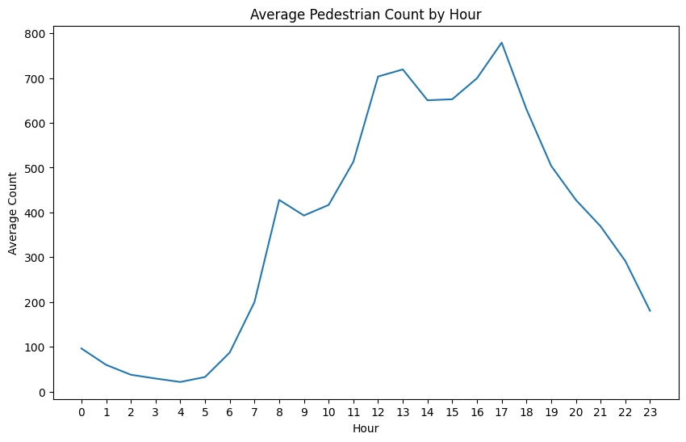

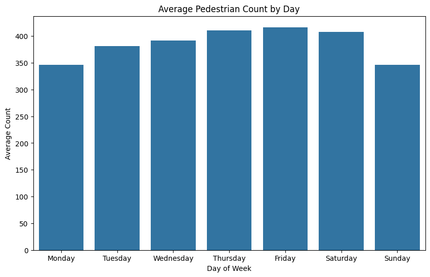

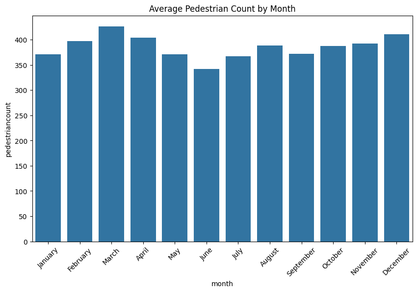

```python
pedestrian_counts_df['sensing_date'] = pd.to_datetime(pedestrian_counts_df['sensing_date'])
pedestrian_counts_df['hour'] = pedestrian_counts_df['hourday'].astype(int)
pedestrian_counts_df['day_of_week'] = pedestrian_counts_df['sensing_date'].dt.day_name()
pedestrian_counts_df['month'] = pedestrian_counts_df['sensing_date'].dt.month_name()

# Hourly trend
hourly_avg = pedestrian_counts_df.groupby('hour')['pedestriancount'].mean().reset_index()
sns.lineplot(data=hourly_avg, x='hour', y='pedestriancount')
plt.title("Average Pedestrian Count by Hour")
plt.xlabel("Hour")
plt.ylabel("Average Count")
plt.xticks(range(0, 24))
plt.show()

# Daily trend
daily_avg = pedestrian_counts_df.groupby('day_of_week')['pedestriancount'].mean().reset_index()
sns.barplot(data=daily_avg, x='day_of_week', y='pedestriancount',order=['Monday','Tuesday','Wednesday','Thursday','Friday','Saturday','Sunday'])
plt.title("Average Pedestrian Count by Day")
plt.xlabel("Day of Week")
plt.ylabel("Average Count")
plt.show()

# Monthly trend
monthly_avg = pedestrian_counts_df.groupby('month')['pedestriancount'].mean().reset_index()
sns.barplot(data=monthly_avg, x='month', y='pedestriancount',order=['January','February','March','April','May','June','July','August','September','October','November','December'])
plt.title("Average Pedestrian Count by Month")
plt.xticks(rotation=45)
plt.show()
```

## Analysing Footpath Availability

This code converts the footpaths dataset into a GeoDataFrame by extracting latitude and longitude from geo_point_2d, creating point geometries, and setting the coordinate reference system to EPSG:4326 for spatial analysis.

```python
footpaths_df = footpaths_df.copy()

footpaths_df[['lat', 'lon']] = footpaths_df['geo_point_2d'].str.split(',', expand=True).astype(float)

footpaths_df.dropna(subset=['lat', 'lon'], inplace=True)

footpaths_df['geometry'] = [Point(xy) for xy in zip(footpaths_df['lon'], footpaths_df['lat'])]

footpaths_gdf = gpd.GeoDataFrame(footpaths_df, geometry='geometry')
footpaths_gdf.set_crs(epsg=4326, inplace=True)

print(footpaths_gdf.head(10))
```

```
                              geo_point_2d  \
0  -37.815961080824124, 144.98832531320022
1    -37.8085534639264, 144.97639258466387
2   -37.82277605089236, 144.93916171174936
3    -37.82928417509253, 144.9694946357787
4   -37.791735093497834, 144.9356096446368
5     -37.81614560851887, 144.958578099413
6   -37.79704499860942, 144.91945533976192
7    -37.79864849576223, 144.9265682087075
8   -37.80998374368285, 144.97348486320715
9   -37.812019717025734, 144.9711776559789

                                           geo_shape  prop_id  shape_stle  \
0  {"coordinates": [[[[144.98810598819998, -37.81...        0  105.419673
1  {"coordinates": [[[[144.9763062409881, -37.808...        0   98.491585
```

[output cut: 46 more lines]

In this step, we changed the footpaths data to match the map’s coordinate system and plots it on an interactive map with an OpenStreetMap background.

[figure not shown]

```python
footpaths_gdf = footpaths_gdf.to_crs(epsg=3857)

ax = footpaths_gdf.plot(figsize=(8, 8), markersize=5, alpha=0.7)
ctx.add_basemap(ax, source=ctx.providers.OpenStreetMap.Mapnik)
```

In this step, I tried to create a heatmap using Folium to show areas with higher footpath density across Melbourne for easy visual analysis.

```python
footpaths_latlon = footpaths_gdf.to_crs(epsg=4326)

m = folium.Map(location=[-37.81, 144.96], zoom_start=13)

heat_data = [[ row['lat'], row['lon']] for idx, row in footpaths_latlon.iterrows()]
HeatMap(heat_data).add_to(m)

m
```

Make this Notebook Trusted to load map: File -> Trust Notebook

[interactive chart not shown]

The heatmap shows areas in central Melbourne with high footpath density, where red regions indicate the highest concentration of footpaths. These high-density zones suggest better pedestrian infrastructure and more walkable areas, while outer blue zones represent lower footpath coverage. This aligns with our prior analysis, which also highlighted strong footpath presence in the city centre and reduced coverage in surrounding areas.

In this step, I converted the pedestrian counts data into a GeoDataFrame by extracting coordinates and creating point geometries for spatial analysis.

```python
pedestrian_counts_df[['lat', 'lon']] = pedestrian_counts_df['location'].str.split(',', expand=True)
pedestrian_counts_df['lat'] = pedestrian_counts_df['lat'].astype(float)
pedestrian_counts_df['lon'] = pedestrian_counts_df['lon'].astype(float)

pedestrian_counts_df['geometry'] = pedestrian_counts_df.apply(lambda row: Point(row['lon'], row['lat']), axis=1)

pedestrian_gdf = gpd.GeoDataFrame(pedestrian_counts_df, geometry='geometry', crs='EPSG:4326')
```

This code implements spatial joins to link footpath and pedestrian data with their corresponding localities based on location, enabling suburb-level analysis of footpath availability and pedestrian activity patterns.

```python
localities = localities_df.to_crs(epsg=4326)
footpaths_gdf = footpaths_gdf.to_crs(epsg=4326)
pedestrian_gdf = pedestrian_gdf.to_crs(epsg=4326)

fp_join = gpd.sjoin(footpaths_gdf, localities, how="inner", predicate="within")

pd_join = gpd.sjoin(pedestrian_gdf, localities, how="inner", predicate="within")
```

In this step, I grouped the footpath data by suburb (gazetted_locality_name) and counted the number of footpath segments in each area to create a footpath_count column for further analysis.

```python
fp_counts = fp_join.groupby('gazetted_locality_name').size().reset_index(name='footpath_count')
fp_counts = fp_counts.sort_values(by='footpath_count', ascending=False)
fp_counts
```

|  | gazetted_locality_name | footpath_count |
| --- | --- | --- |
| 6 | MELBOURNE | 2626 |
| 5 | KENSINGTON | 1812 |
| 2 | DOCKLANDS | 1694 |
| 0 | CARLTON | 1212 |
| 7 | NORTH MELBOURNE | 1190 |
| 8 | PARKVILLE | 896 |
| 3 | EAST MELBOURNE | 886 |
| 15 | WEST MELBOURNE | 701 |
| 14 | SOUTHBANK | 563 |
| 13 | SOUTH YARRA | 341 |
| 9 | PORT MELBOURNE | 146 |
| 1 | CARLTON NORTH | 115 |
| 4 | FLEMINGTON | 26 |
| 12 | SOUTH WHARF | 6 |
| 10 | PRINCES HILL | 2 |
| 11 | SOUTH MELBOURNE | 1 |

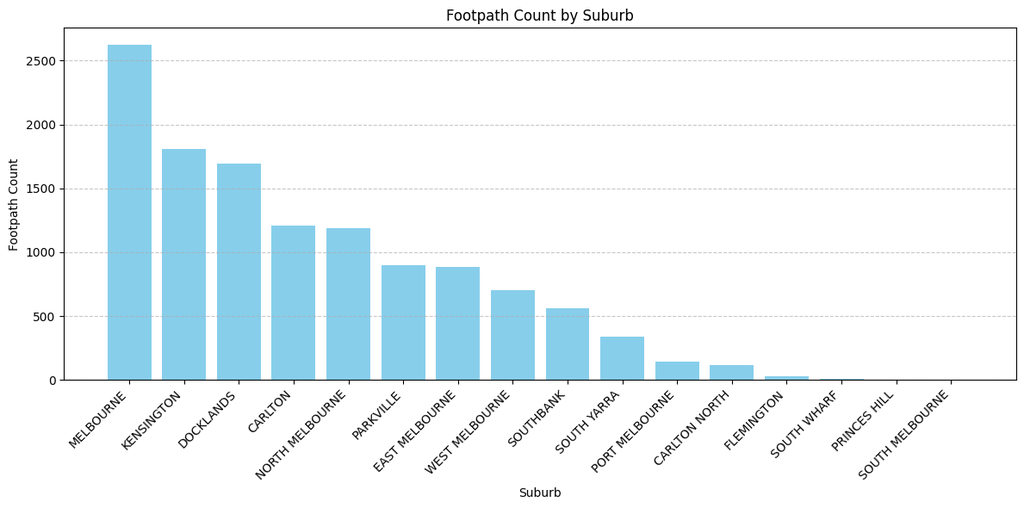

```python
plt.figure(figsize=(12, 6))
plt.bar(fp_counts['gazetted_locality_name'], fp_counts['footpath_count'], color='skyblue')
plt.xticks(rotation=45, ha='right')
plt.xlabel('Suburb')
plt.ylabel('Footpath Count')
plt.title('Footpath Count by Suburb')
plt.tight_layout()
plt.grid(axis='y', linestyle='--', alpha=0.7)
plt.show()
```

The suburb of Melbourne has the highest number of footpath segments (2,626), followed by Kensington (1,812), Docklands (1,694), and Carlton (1,212), indicating strong pedestrian infrastructure in these areas. In contrast, suburbs like South Wharf (6), Princes Hill (2), and South Melbourne (1) show very limited footpath coverage, suggesting lower walkability or less developed infrastructure. This variation highlights the uneven distribution of footpath networks across different parts of the city.

```python
pd_counts = pd_join.groupby('gazetted_locality_name')['hourday'].sum().reset_index(name='pedestrian_count')
pd_counts = pd_counts.sort_values(by='pedestrian_count', ascending=False)
pd_counts
```

|  | gazetted_locality_name | pedestrian_count |
| --- | --- | --- |
| 3 | MELBOURNE | 10634234 |
| 1 | DOCKLANDS | 2250395 |
| 0 | CARLTON | 879756 |
| 7 | SOUTHBANK | 751193 |
| 4 | NORTH MELBOURNE | 590732 |
| 5 | PARKVILLE | 484793 |
| 2 | KENSINGTON | 436058 |
| 8 | WEST MELBOURNE | 413283 |
| 6 | SOUTH WHARF | 196826 |

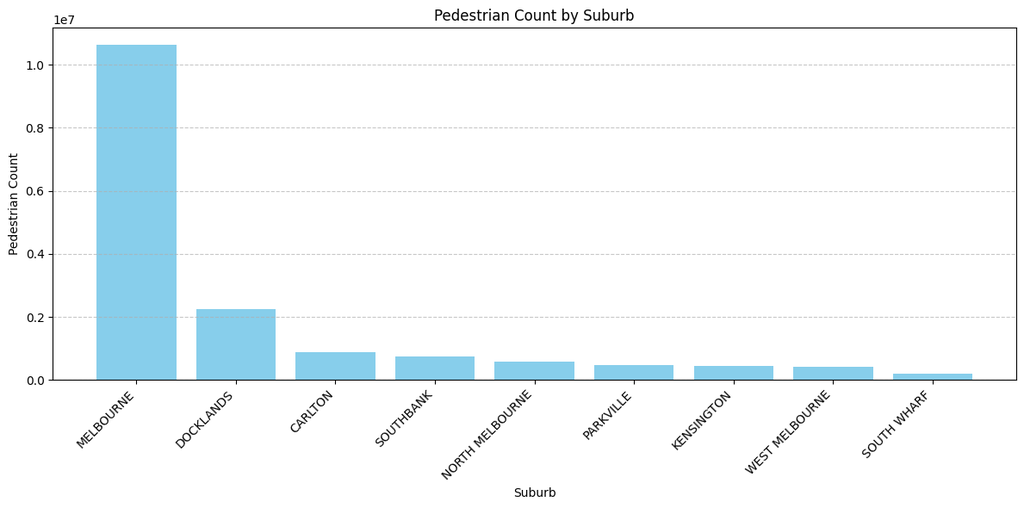

```python
plt.figure(figsize=(12, 6))
plt.bar(pd_counts['gazetted_locality_name'], pd_counts['pedestrian_count'], color='skyblue')
plt.xticks(rotation=45, ha='right')
plt.xlabel('Suburb')
plt.ylabel('Pedestrian Count')
plt.title('Pedestrian Count by Suburb')
plt.tight_layout()
plt.grid(axis='y', linestyle='--', alpha=0.7)
plt.show()
```

In this step, I merged footpath and pedestrian counts by suburb and sorted them to compare areas with the highest pedestrian activity and footpath coverage.

```python
comparison_df = fp_counts.merge(pd_counts, on='gazetted_locality_name')
comparison_df = comparison_df.sort_values(by=['pedestrian_count','footpath_count'], ascending=False)

comparison_df
```

|  | gazetted_locality_name | footpath_count | pedestrian_count |
| --- | --- | --- | --- |
| 0 | MELBOURNE | 2626 | 10634234 |
| 2 | DOCKLANDS | 1694 | 2250395 |
| 3 | CARLTON | 1212 | 879756 |
| 7 | SOUTHBANK | 563 | 751193 |
| 4 | NORTH MELBOURNE | 1190 | 590732 |
| 5 | PARKVILLE | 896 | 484793 |
| 1 | KENSINGTON | 1812 | 436058 |
| 6 | WEST MELBOURNE | 701 | 413283 |
| 8 | SOUTH WHARF | 6 | 196826 |

```python
print("Correlation between footpath density and pedestrian activity:")
print(comparison_df['footpath_count'].corr(comparison_df['pedestrian_count']))
```

```
Correlation between footpath density and pedestrian activity:
0.7530038220010572
```

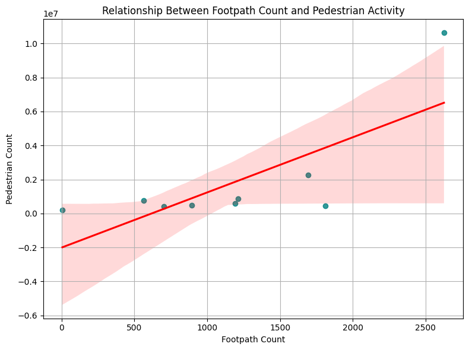

```python
# Scatter plot with regression line
plt.figure(figsize=(8, 6))
sns.regplot(data=comparison_df, x='footpath_count', y='pedestrian_count', color='teal', line_kws={"color": "red"})
plt.xlabel('Footpath Count')
plt.ylabel('Pedestrian Count')
plt.title('Relationship Between Footpath Count and Pedestrian Activity')
plt.grid(True)
plt.tight_layout()
plt.show()
```

This scatter plot with a regression line shows a strong positive relationship between footpath count and pedestrian activity across suburbs. The upward trend indicates that areas with more footpaths tend to have higher pedestrian movement. However, the spread of points also shows variability—some suburbs with high footpath counts have moderate pedestrian use, and vice versa. This suggests that while footpath availability supports walkability, other factors like land use, attractions, and population density may also influence pedestrian activity.

```python
# footpaths per 1000 pedestrians
comparison_df['footpaths_per_1000_peds'] = (comparison_df['footpath_count'] / comparison_df['pedestrian_count']) * 1000
comparison_df_sorted = comparison_df.sort_values(by='footpaths_per_1000_peds', ascending=False)
print(comparison_df_sorted[['gazetted_locality_name', 'footpaths_per_1000_peds']])
```

```
  gazetted_locality_name  footpaths_per_1000_peds
1             KENSINGTON                 4.155411
4        NORTH MELBOURNE                 2.014450
5              PARKVILLE                 1.848212
6         WEST MELBOURNE                 1.696174
3                CARLTON                 1.377655
2              DOCKLANDS                 0.752757
7              SOUTHBANK                 0.749475
0              MELBOURNE                 0.246938
8            SOUTH WHARF                 0.030484
```

This metric helps pinpoint areas where footpath development may be needed to better support walking activity.

## Analysing Playground Proximity for Pedestrian Activity

The below code matches each pedestrian sensor with its nearest playground, calculates the walking distance, and flags whether the sensor is within 800 m of a playground to study how playground proximity may influence pedestrian activity.

```python
plt.rcParams['figure.figsize'] = (10, 6)

def to_projected(gdf, epsg_m=7855):
    gdf = gdf.set_crs(4326, allow_override=True) if gdf.crs is None else gdf.to_crs(4326)
    return gdf.to_crs(epsg=epsg_m)

def plot_group_timeseries(df, group_col, y_col='pedestriancount', x_col='hour', title=''):
    pivot = df.pivot_table(index=x_col, columns=group_col, values=y_col, aggfunc='mean')
    pivot.plot(marker='o')
    plt.title(title); plt.xlabel(x_col.capitalize()); plt.ylabel(f'Avg {y_col}')
    plt.grid(True, alpha=0.3); plt.show()

# ===== Pedestrian points =====
ped_df = pedestrian_counts_df.copy()
ped_df['sensing_date'] = pd.to_datetime(ped_df['sensing_date'], errors='coerce')
if 'hour' in ped_df.columns:
    ped_df['hour'] = pd.to_numeric(ped_df['hour'], errors='coerce').astype('Int64')

ped_gdf = gpd.GeoDataFrame(
    ped_df,
    geometry=gpd.points_from_xy(ped_df['lon'], ped_df['lat']),
    crs="EPSG:4326"
)
ped_gdf_m = to_projected(ped_gdf, epsg_m=7855)

# ===== Playgrounds points (parse geo_point_2d -> lat/lon) =====
pg_src = playgrounds_df.copy()
if not {'lon','lat'}.issubset(pg_src.columns):
    coords = pg_src['geo_point_2d'].astype(str).str.split(',', n=1, expand=True)
    pg_src['lat'] = pd.to_numeric(coords[0].str.strip(), errors='coerce')
    pg_src['lon'] = pd.to_numeric(coords[1].str.strip(), errors='coerce')
pg_src = pg_src.dropna(subset=['lat','lon']).copy()
if 'name' not in pg_src.columns:
    # fallback label if name missing
    pg_src['name'] = pg_src.get('features', pg_src.index).astype(str)

pg_gdf = gpd.GeoDataFrame(
    pg_src,
    geometry=gpd.points_from_xy(pg_src['lon'], pg_src['lat']),
    crs="EPSG:4326"
)
pg_gdf_m = to_projected(pg_gdf, epsg_m=7855)

# ===== Nearest join =====
ped_near = gpd.sjoin_nearest(
    ped_gdf_m,
    pg_gdf_m[['geometry','name']],
    how='left',
    distance_col='dist_to_playground_m'
).to_crs(4326)

# ===== Flag within radius =====
RADIUS_M = 800
near_col = f'near_playground_{RADIUS_M}m'
ped_near[near_col] = (ped_near['dist_to_playground_m'] <= RADIUS_M).astype(int)

# ===== Quick check =====
display_cols = ['sensor_name','pedestriancount','name','dist_to_playground_m', near_col]
display_cols = [c for c in display_cols if c in ped_near.columns]
ped_near[display_cols].head()
```

|  | sensor_name | pedestriancount | name | dist_to_playground_m | near_playground_800m |
| --- | --- | --- | --- | --- | --- |
| 0 | Spen161_T | 452 | Docklands Park Playground | 725.826020 | 1 |
| 1 | Spen161_T | 824 | Docklands Park Playground | 725.826020 | 1 |
| 2 | Spen161_T | 503 | Docklands Park Playground | 725.826020 | 1 |
| 3 | 280Will_T | 2 | Flagstaff Gardens Playground | 378.451615 | 1 |
| 4 | Fli114C_T | 7 | Birrarung Marr Artplay | 204.162639 | 1 |

The results show that being close to a playground does not always translate into higher pedestrian activity. For example, some sensors within 200–400 metres record very low counts, while others nearly 700–800 metres away capture some of the busiest flows. This suggests that playground proximity alone is not a strong driver of pedestrian movement, with factors such as time of day, surrounding land use, and nearby attractions playing a larger role

This code compares pedestrian activity at sensors located near playgrounds (within the set radius) versus those further away. It summarises counts (mean, median, std), then visualises differences with a boxplot, and plots hourly and day-of-week trends to show how activity patterns vary between near and far locations.

```
                        count        mean  median         std
near_playground_800m
far                    101211  583.572507   315.0  708.674952
near                  1306792  370.629637   158.0  553.959069
```

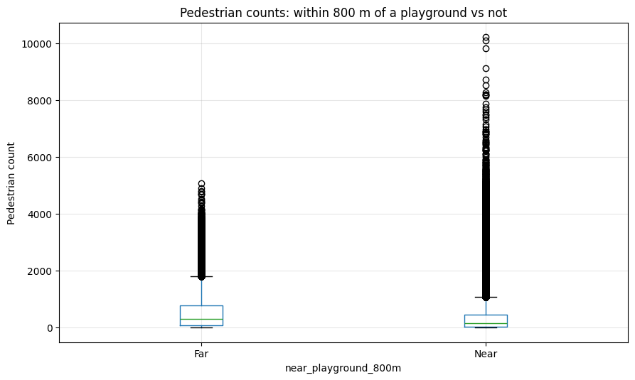

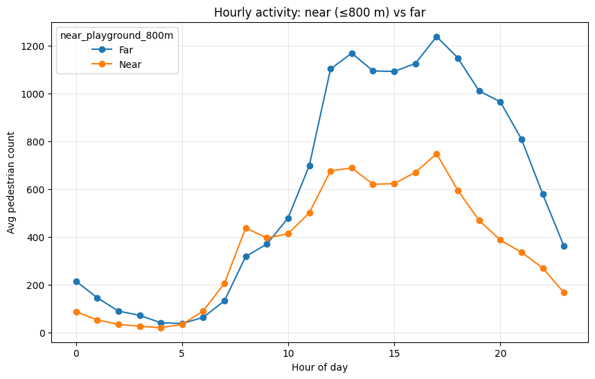

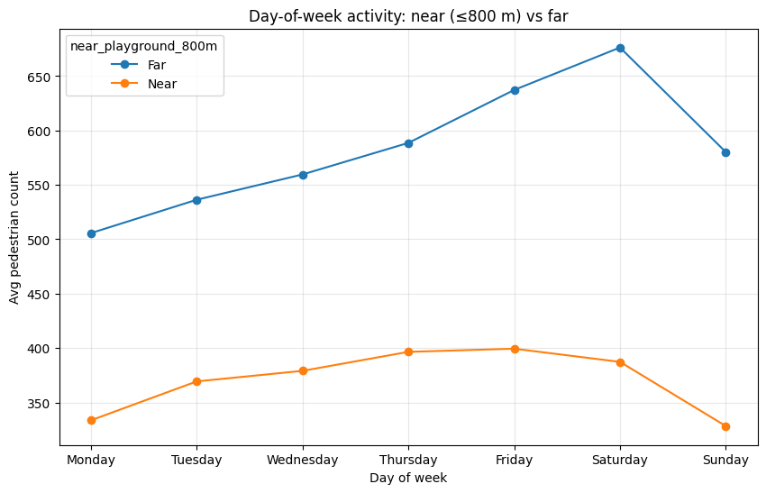

```python
NEAR_COL = f'near_playground_{RADIUS_M}m'

if 'hour' in ped_near.columns:
    ped_near['hour'] = ped_near['hour'].astype(int, errors='ignore')

summary = (ped_near
           .groupby(NEAR_COL)['pedestriancount']
           .agg(count='count', mean='mean', median='median', std='std')
           .rename(index={0:'far', 1:'near'})
          )
print(summary)

# --- Boxplot: near vs far ---
ped_near.boxplot(column='pedestriancount', by=NEAR_COL)
plt.title(f'Pedestrian counts: within {RADIUS_M} m of a playground vs not')
plt.suptitle('')
plt.xticks([1,2], ['Far', 'Near'])
plt.ylabel('Pedestrian count')
plt.grid(True, alpha=0.3)
plt.show()

# --- Hour-of-day mean curve: near vs far ---
if 'hour' in ped_near.columns:
    pivot_h = (ped_near
               .pivot_table(index='hour', columns=NEAR_COL, values='pedestriancount', aggfunc='mean')
               .rename(columns={0:'Far', 1:'Near'}))
    pivot_h.plot(marker='o')
    plt.title(f'Hourly activity: near (≤{RADIUS_M} m) vs far')
    plt.xlabel('Hour of day')
    plt.ylabel('Avg pedestrian count')
    plt.grid(True, alpha=0.3)
    plt.show()

# --- Day-of-week mean curve: near vs far ---
if 'day_of_week' in ped_near.columns:
    dow_order = ['Monday','Tuesday','Wednesday','Thursday','Friday','Saturday','Sunday']
    ped_near['day_of_week'] = pd.Categorical(ped_near['day_of_week'], categories=dow_order, ordered=True)

    pivot_d = (ped_near
               .groupby(['day_of_week', NEAR_COL], observed=False)['pedestriancount']
               .mean()
               .reset_index()
               .pivot(index='day_of_week', columns=NEAR_COL, values='pedestriancount')
               .rename(columns={0:'Far', 1:'Near'}))
    pivot_d.plot(marker='o')
    plt.title(f'Day-of-week activity: near (≤{RADIUS_M} m) vs far')
    plt.xlabel('Day of week')
    plt.ylabel('Avg pedestrian count')
    plt.grid(True, alpha=0.3)
    plt.show()
```

## Analysing Apartment Share from Resident Profiles and Pedestrian Activity

This code takes the resident profiles data to calculate the share of apartments in Greater Melbourne by year. It then combines this with yearly pedestrian counts, matches years between the two datasets, and finally checks if there is a relationship between apartment share and pedestrian activity using a scatter plot.

```
Merged preview:
    year    ped_mean    ped_sum  ped_count  res_year  apartment_share
0  2023  416.282245   79869993     191865      2016         0.149294
1  2024  385.451255  269203782     698412      2016         0.149294
2  2025  375.345310  194326026     517726      2016         0.149294
Rows with apartment_share: 3 / 3
```

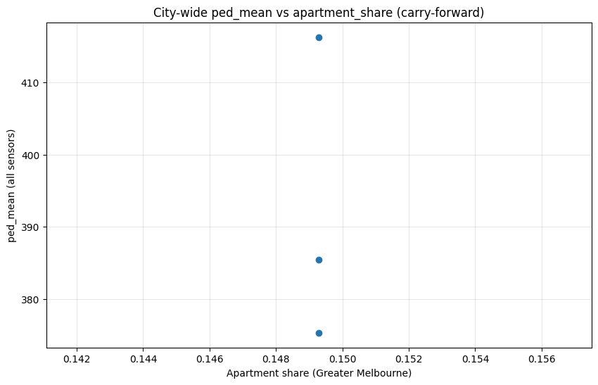

```python
rp = resident_profiles_df.copy()
rp['year']  = pd.to_numeric(rp['year'], errors='coerce')
rp['value'] = pd.to_numeric(rp['value'], errors='coerce')

gm = rp[rp['geography'].str.contains('Greater Melbourne', case=False, na=False)]
if gm.empty:
    gm = rp[rp['geography'].str.contains('Melbourne', case=False, na=False)]

is_dwell = (
    gm['topic'].str.contains('Dwellings', case=False, na=False) &
    gm['category'].str.contains('Dwelling type - detailed', case=False, na=False) &
    gm['value_description'].eq('Count of occupied private dwellings')
)
dw = gm.loc[is_dwell, ['year','sub_category','value']].copy()

tot = dw.groupby('year', as_index=False)['value'].sum().rename(columns={'value':'total_dw'})
apt = (dw[dw['sub_category'].str.contains('apartment|flat', case=False, na=False)]
       .groupby('year', as_index=False)['value'].sum()
       .rename(columns={'value':'apt_dw'}))
res_feat = tot.merge(apt, on='year', how='left')
res_feat['apartment_share'] = res_feat['apt_dw'] / res_feat['total_dw']
res_feat = res_feat[['year','apartment_share']].drop_duplicates().dropna(subset=['year'])

# ---------- 2) Pedestrian: city-wide by year
ped = pedestrian_counts_df.copy()
ped['sensing_date'] = pd.to_datetime(ped['sensing_date'], errors='coerce')
ped = ped.dropna(subset=['sensing_date','pedestriancount'])
ped['year'] = ped['sensing_date'].dt.year

ped_year = (ped.groupby('year', as_index=False)['pedestriancount']
              .agg(ped_mean='mean', ped_sum='sum', ped_count='size'))

# ---------- 3) Carry-forward resident year to each ped year
avail = np.sort(res_feat['year'].dropna().unique())
def carry_forward(y):
    prev = avail[avail <= y]
    return prev.max() if prev.size else (avail.min() if avail.size else np.nan)

ped_year['res_year'] = ped_year['year'].apply(carry_forward)

merged = ped_year.merge(res_feat.rename(columns={'year':'res_year'}),
                        on='res_year', how='left')

print("Merged preview:\n", merged.head())
print("Rows with apartment_share:", merged['apartment_share'].notna().sum(), "/", len(merged))

have = merged.dropna(subset=['apartment_share'])
if len(have) >= 2:
    corr = have[['ped_mean','apartment_share']].corr(method='spearman').loc['ped_mean','apartment_share']
    # Scatter with best-fit line
    x = have['apartment_share'].to_numpy()
    y = have['ped_mean'].to_numpy()
    X = np.c_[np.ones(len(x)), x]
    b, *_ = np.linalg.lstsq(X, y, rcond=None)

    xs = np.linspace(np.nanmin(x), np.nanmax(x), 100)
    ys = b[0] + b[1]*xs

    plt.figure()
    plt.scatter(x, y)
    plt.plot(xs, ys)
    plt.title('City-wide ped_mean vs apartment_share (carry-forward)')
    plt.xlabel('Apartment share (Greater Melbourne)')
    plt.ylabel('ped_mean (all sensors)')
    plt.grid(True, alpha=0.3)
    plt.show()
else:
    print("\nNot enough matched years to plot (need ≥2). Check res years present in resident data.")
```

The scatter plot shows that the apartment share value (about 15%) stayed constant across the matched years, while average pedestrian counts varied. Because there is no change in apartment share, we cannot draw any meaningful relationship between apartment density and pedestrian activity from this dataset. This highlights a limitation in the available resident profiles data, as more recent updates or finer geographic detail would be needed to explore the link properly.

## Estimating the Effect of Playground Proximity on Pedestrian Activity

This code creates a daily dataset per sensor, labels sensors near a playground as the “treatment” (T=1), and then uses Coarsened Exact Matching (CEM) on time (month, weekday) and coarse location (lat/lon quantiles) to compute the ATT—the average difference in daily pedestrian counts between near vs. far sensors within comparable strata.

```python
df = ped_near[['id','sensor_name','sensing_date','day_of_week','lat','lon',
               'pedestriancount','dist_to_playground_m'] +
              [c for c in ped_near.columns if str(c).startswith('near_playground_')]].copy()

df['sensing_date'] = pd.to_datetime(df['sensing_date'], errors='coerce')
df = df.dropna(subset=['sensing_date','pedestriancount'])

near_col = next((c for c in df.columns if str(c).startswith('near_playground_')
                 and set(df[c].dropna().unique()).issubset({0,1})), None)
if near_col is None:
    raise KeyError("No binary proximity flag found. Expected a column like 'near_playground_800m'.")

# --- Daily outcome per sensor (silence future warning) ---
daily = (df.groupby(['sensor_name','sensing_date','day_of_week'], as_index=False, observed=False)
           ['pedestriancount'].mean()
           .rename(columns={'pedestriancount':'y'}))

# Treatment + coordinates at sensor level
sensor_T  = df.groupby('sensor_name', as_index=False, observed=False)[near_col].max().rename(columns={near_col:'T'})
sensor_xy = (df.groupby('sensor_name', as_index=False, observed=False)
               .agg(lat=('lat','mean'), lon=('lon','mean')))

xy = (daily.merge(sensor_T,  on='sensor_name', how='left')
           .merge(sensor_xy, on='sensor_name', how='left'))
xy['T'] = xy['T'].fillna(0).astype(int)
xy['month'] = xy['sensing_date'].dt.month
# if day_of_week missing/NaN, derive from date
if 'day_of_week' not in xy or xy['day_of_week'].isna().all():
    xy['day_of_week'] = xy['sensing_date'].dt.day_name()
xy['day_of_week'] = xy['day_of_week'].astype(str)

print("Treated obs:", int((xy['T']==1).sum()), "| Control obs:", int((xy['T']==0).sum()))

def cem_att(frame, keys):
    g = frame.groupby(keys + ['T'], observed=False)['y'].mean().unstack()
    n = frame.groupby(keys + ['T'], observed=False)['y'].size().unstack().fillna(0)
    valid = g.dropna()                   # strata with BOTH T=0 and T=1
    if valid.empty:
        return np.nan, 0, 0
    att_s = (valid[1] - valid[0])        # diff in means per stratum
    w = n.loc[valid.index, 1]            # weight by treated count (ATT)
    ATT = (att_s * w).sum() / (w.sum() if w.sum() else np.nan)
    return ATT, len(valid), int(w.sum())


def qbins(s, q=5):
    q = min(q, s.nunique(dropna=True)) if s.notna().any() else 1
    if q < 2:
        return pd.Series(['ALL']*len(s), index=s.index)
    return pd.qcut(s, q=q, duplicates='drop').astype(str)

xy = xy.copy()
xy['lat_q'] = qbins(xy['lat'], q=5)
xy['lon_q'] = qbins(xy['lon'], q=5)

# Try from most specific to most general
key_sets = [
    ['month','day_of_week','lat_q','lon_q'],
    ['month','lat_q','lon_q'],
    ['month','day_of_week'],
    ['month']
]

ATT = np.nan; used = None; strata_used = 0; treated_used = 0
for keys in key_sets:
    att, k, tw = cem_att(xy, keys)
    if not np.isnan(att):
        ATT, used, strata_used, treated_used = att, keys, k, tw
        break

if used is not None:
    print(f"✓ CEM ATT computed over keys {used} | Strata used: {strata_used} | Treated obs used: {treated_used}")
    print(f"ATT (near - far) on daily mean ped count ≈ {ATT:.2f}")
else:
    print("No overlapping strata even after coarsening → falling back to fast OLS adjustment.")

    # --- Fallback: tiny OLS with month & DOW dummies + lat/lon continuous ---
    xy2 = xy.dropna(subset=['y']).copy()
    xy2['lat_s'] = (xy2['lat'] - xy2['lat'].mean()) / (xy2['lat'].std(ddof=0) or 1)
    xy2['lon_s'] = (xy2['lon'] - xy2['lon'].mean()) / (xy2['lon'].std(ddof=0) or 1)

    X = pd.get_dummies(xy2[['month','day_of_week']], drop_first=True)
    X = pd.concat([
        pd.Series(1.0, index=xy2.index, name='intercept'),
        xy2['T'].astype(float).rename('T'),
        xy2[['lat_s','lon_s']].astype(float),
        X
    ], axis=1)

    Y = xy2['y'].to_numpy(dtype=float)
    beta, *_ = np.linalg.lstsq(X.to_numpy(dtype=float), Y, rcond=None)
    tau = float(beta[1])  # coefficient on T

    print(f"OLS adjusted effect of proximity (tau) ≈ {tau:.2f}  (units: daily mean ped count)")
```

```
Treated obs: 465647 | Control obs: 35819
✓ CEM ATT computed over keys ['month', 'day_of_week', 'lat_q', 'lon_q'] | Strata used: 273 | Treated obs used: 62692
ATT (near - far) on daily mean ped count ≈ -76.69
```

After comparing like-for-like times and places (same month, weekday, and similar location bands), sensors near playgrounds show lower daily pedestrian counts than comparable sensors that are farther away (about 77 fewer people per day on average). This suggests that playground adjacency is not a primary driver of pedestrian volumes in the city network; instead, activity appears to be led by major trip generators such as CBD corridors, transport interchanges, offices, retail streets, and other mixed-use destinations.

In practical terms, we should not assume higher footfall simply because a site is within an 800 m walk of a playground. For planning or investment decisions aimed at boosting walking, the evidence points toward focusing on land-use intensity, connectivity to transit, and commercial frontage rather than playground proximity alone.

## Clustering Pedestrian Sensors by Activity and Playground Proximity

This code creates a feature set for each pedestrian sensor using its average count, variability, distance to the nearest playground, coordinates, and a binary flag for being within 800 m of a playground. The features are scaled and then grouped into 3 clusters using K-Means. The result helps to identify different types of sensor locations (e.g., consistently busy, moderately active, or quieter sites) and whether playground proximity plays a role in how sensors group together.

```python
base = (pedestrian_counts_df.groupby('sensor_name', observed=False)['pedestriancount']
          .agg(ped_mean='mean', ped_std='std').reset_index())
near = (ped_near.groupby('sensor_name', observed=False)
          .agg(dist_to_playground_m=('dist_to_playground_m','min'),
               lat=('lat','mean'), lon=('lon','mean'))
          .reset_index())

feat = base.merge(near, on='sensor_name', how='left')
# Binary near flag (≤800 m)
feat['near_800m'] = (feat['dist_to_playground_m'] <= 800).astype(int)

# Select features and scale
X = feat[['ped_mean','ped_std','dist_to_playground_m','lat','lon','near_800m']].fillna(0)
X_scaled = StandardScaler().fit_transform(X)


k = 3
km = KMeans(n_clusters=k, random_state=42, n_init='auto')
feat['cluster'] = km.fit_predict(X_scaled)

print("Sensors per cluster:\n", feat['cluster'].value_counts().sort_index())
print(feat.head())
```

```
Sensors per cluster:
 cluster
0    32
1    21
2    45
Name: count, dtype: int64
  sensor_name    ped_mean     ped_std  dist_to_playground_m        lat  \
0   261Will_T  400.269497  495.030307            422.313520 -37.812958
1   280Will_T  153.011451  123.518035            378.451615 -37.812463
2     474Fl_T  207.865036  122.810587            740.477834 -37.819973
3    488Mac_T   94.453341   76.742372            138.861810 -37.794324
4    574Qub_T   60.634630   48.456026            504.299732 -37.803100

          lon  near_800m  cluster
0  144.956788          1        2
1  144.956902          1        0
2  144.958349          1        2
3  144.929734          1        0
4  144.949081          1        0
```

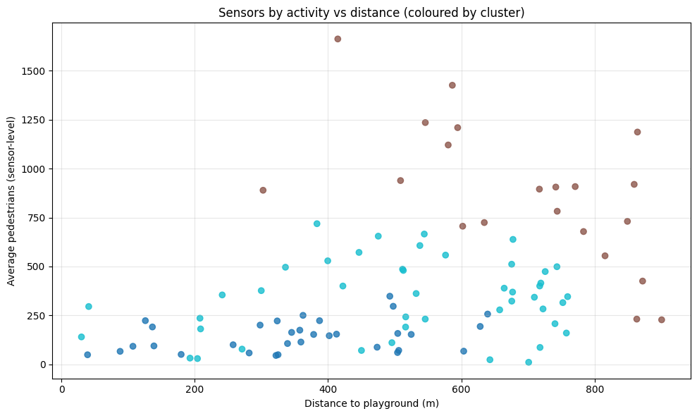

```python
plt.figure()
plt.scatter(feat['dist_to_playground_m'], feat['ped_mean'], c=feat['cluster'], cmap='tab10', alpha=0.8)
plt.xlabel('Distance to playground (m)')
plt.ylabel('Average pedestrians (sensor-level)')
plt.title('Sensors by activity vs distance (coloured by cluster)')
plt.grid(True, alpha=0.3)
plt.tight_layout()
plt.show()
```

The clustering reinforces earlier results—playground proximity has little influence on overall pedestrian activity levels. Instead, clusters reflect intensity of urban use, with busy corridors dominating pedestrian flows regardless of playground distance.

## Detecting Unusual Pedestrian Days

This code builds a daily per-sensor table and adds simple context features (month, weekend flag, distance to nearest playground). It scales the features and uses Isolation Forest to flag anomalous days where pedestrian counts are unexpectedly high/low given the context. The output lists the top unusual sensor-days with their anomaly scores so we can investigate events, data issues, or special conditions.

```python
# ---- Build daily table per sensor ----
df = ped_near[['sensor_name','sensing_date','pedestriancount','dist_to_playground_m']].copy()
df['sensing_date'] = pd.to_datetime(df['sensing_date'], errors='coerce')
df = df.dropna(subset=['sensing_date','pedestriancount'])

daily = (df.groupby(['sensor_name','sensing_date'], observed=False)['pedestriancount']
           .mean().rename('y').reset_index())

# Static sensor features
sensor_ctx = (df.groupby('sensor_name', observed=False)
                .agg(dist_to_playground_m=('dist_to_playground_m','min'))
                .reset_index())

Xy = daily.merge(sensor_ctx, on='sensor_name', how='left')
Xy['month']   = Xy['sensing_date'].dt.month
Xy['weekend'] = Xy['sensing_date'].dt.dayofweek.isin([5,6]).astype(int)

# Feature matrix (keep tiny)
feat_cols = ['y','month','weekend','dist_to_playground_m']
X = Xy[feat_cols].fillna(0).astype(float)

# Scale + Isolation Forest
X_scaled = StandardScaler().fit_transform(X)
iso = IsolationForest(n_estimators=200, contamination=0.01, random_state=42)
pred = iso.fit_predict(X_scaled)
score = iso.decision_function(X_scaled)  # lower = more anomalous

Xy['anomaly'] = (pred == -1).astype(int)
Xy['anomaly_score'] = -score

# Top unusual days (lower score → more unusual)
anoms = (Xy[Xy['anomaly']==1]
         .sort_values('anomaly_score', ascending=False)
         .head(25)[['sensor_name','sensing_date','y','dist_to_playground_m','anomaly_score']])
print("Top anomalies:\n", anoms)
```

```
Top anomalies:
         sensor_name sensing_date            y  dist_to_playground_m  \
5949   BirArt1109_T   2025-03-09  2421.888889             41.020368
57278         Swa31   2023-12-17  2881.944444            414.668901
57277         Swa31   2023-12-16  3086.100000            414.668901
57284         Swa31   2023-12-23  2790.650000            414.668901
57292         Swa31   2023-12-31  2604.588235            414.668901
57312         Swa31   2024-01-20  2481.444444            414.668901
57626         Swa31   2024-12-14  2558.947368            414.668901
57633         Swa31   2024-12-21  2539.400000            414.668901
57619         Swa31   2024-12-07  2561.631579            414.668901
57285         Swa31   2023-12-24  2405.166667            414.668901
57264         Swa31   2023-12-03  2463.736842            414.668901
57271         Swa31   2023-12-10  2392.277778            414.668901
49494      SouthB_T   2023-12-31  2622.125000            586.492072
```

[output cut: 39 more lines]

Most extreme spikes cluster around December–February and on weekends/holidays, with repeated hits at Swa31 (mid-Dec to late Jan), plus Birrarung Marr / ArtPlay (BirArt1109_T) and Southbank/Princes sensors. These sites are well-known event and riverfront locations, so the pattern strongly suggests event-driven surges (festivals, New Year’s, summer programming) rather than playground proximity. Distances to playgrounds are modest (≈40–600 m), but the magnitudes (2,300–3,400+ average pedestrians/day on flagged dates) indicate area-wide attractors dominate

```python
def anomaly_summary(Xy):
    a = Xy[Xy['anomaly']==1].copy()
    if a.empty:
        print("No anomalies flagged.");
        return pd.DataFrame()

    a['sensing_date'] = pd.to_datetime(a['sensing_date'])
    a['dow']   = a['sensing_date'].dt.day_name()
    a['month'] = a['sensing_date'].dt.month

    # Baseline per sensor to measure "excess"
    med = Xy.groupby('sensor_name')['y'].median().rename('y_median').reset_index()
    a = a.merge(med, on='sensor_name', how='left')
    a['excess'] = a['y'] - a['y_median']

    # Sensor-level digest
    summary = (a.groupby('sensor_name', as_index=False)
                 .agg(
                     n_anoms=('anomaly','size'),
                     max_score=('anomaly_score','max'),
                     mean_excess=('excess','mean'),
                     top_month=('month', lambda s: s.value_counts().idxmax()),
                     top_dow=('dow',   lambda s: s.value_counts().idxmax())
                 )
               .sort_values(['n_anoms','max_score'], ascending=[False, False]))

    # Top 15 anomaly rows for quick viewing
    top_rows = a.sort_values('anomaly_score', ascending=False)\
                .loc[:, ['sensor_name','sensing_date','y','excess','anomaly_score']]\
                .head(15)

    print("— Sensor-level summary —")
    print(summary.head(12))
    print("\n— Top 15 anomaly rows —")
    print(top_rows)
    return summary


summary = anomaly_summary(Xy)
```

```
— Sensor-level summary —
     sensor_name  n_anoms  max_score  mean_excess  top_month   top_dow
17         Swa31      356   0.060891   312.191216         12  Saturday
14      SouthB_T      103   0.054968   612.703178         12  Saturday
12         QVN_T       71   0.031109   183.987906         12  Saturday
16      Swa295_T       25   0.024684   345.179054         12  Saturday
11       PriNW_T       23   0.052816   734.088909         12  Saturday
15      Swa123_T       21   0.039661   950.489161         12  Saturday
1   BirArt1109_T       16   0.074004  1152.349472          1    Sunday
0           AG_T        7   0.050471  1590.889881          3    Sunday
5         ElFi_T        6   0.021976   488.388889         12  Saturday
3       Bou292_T        4   0.023364   800.484023         12  Saturday
9         MCEC_T        4   0.013467  1226.500000         10  Saturday
8   Hammer1584_T        2   0.014496  1024.510070         12  Saturday

```

[output cut: 17 more lines]

The outliers are predominantly event-driven surges tied to seasonality (summer) and weekends, concentrated along high-amenity/event corridors. They do not indicate an effect of playground proximity. For typical, everyday pedestrian patterns, these anomaly days should be treated as special cases

This function plots each sensor’s daily counts over a ±28-day window around a chosen date, overlays a 7-day rolling median as baseline, and marks the anomaly day. It also compares the hourly profile on the anomaly day with the typical same-weekday pattern, so we can visualise when (and how strongly) the spike deviates from normal

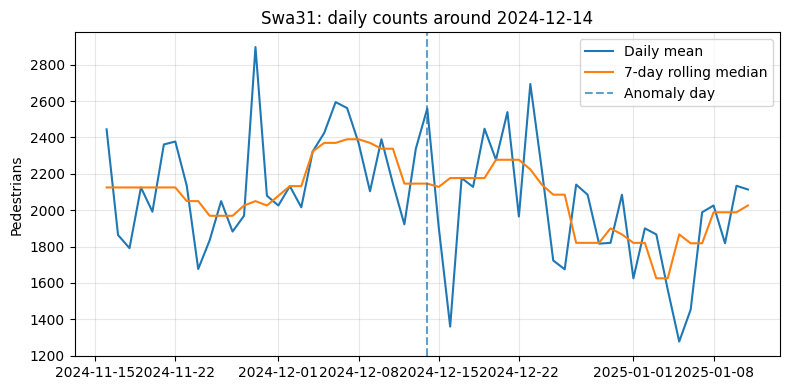

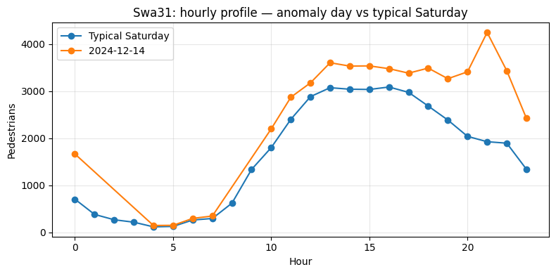

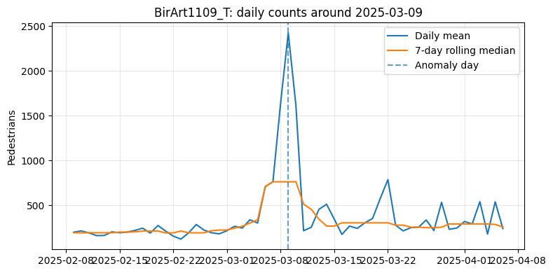

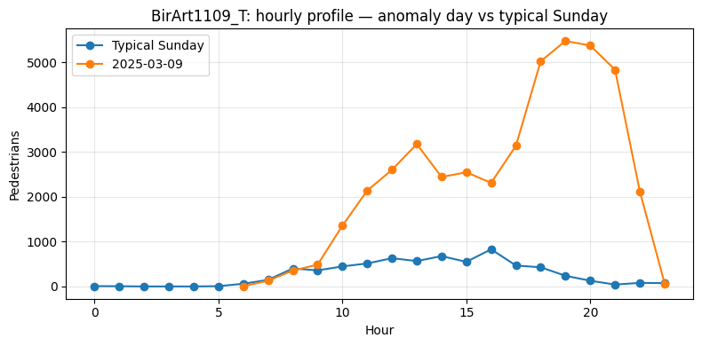

```python
def plot_anomaly_window(sensor_id, date_str, window_days=28):
    day = pd.to_datetime(date_str)

    # Daily series for this sensor
    d0 = (pedestrian_counts_df[['sensor_name','sensing_date','pedestriancount']]
            .query("sensor_name == @sensor_id")
            .assign(sensing_date=lambda x: pd.to_datetime(x['sensing_date']))
            .groupby('sensing_date', observed=False)['pedestriancount'].mean()
            .asfreq('D').fillna(0.0))

    # Window around the anomaly day
    lo, hi = day - pd.Timedelta(days=window_days), day + pd.Timedelta(days=window_days)
    dwin = d0.loc[lo:hi]

    # Rolling baseline + highlight anomaly
    roll = d0.rolling(7, center=True, min_periods=1).median()
    plt.figure(figsize=(8,4))
    plt.plot(dwin.index, dwin.values, label='Daily mean')
    plt.plot(dwin.index, roll.loc[lo:hi].values, label='7-day rolling median')
    plt.axvline(day, ls='--', alpha=0.7, label='Anomaly day')
    plt.title(f'{sensor_id}: daily counts around {day.date()}')
    plt.ylabel('Pedestrians'); plt.grid(True, alpha=0.3); plt.legend(); plt.tight_layout()
    plt.show()

    # Hourly profile: anomaly day vs same-weekday typical
    dfh = (pedestrian_counts_df[['sensor_name','sensing_date','hour','pedestriancount']]
             .query("sensor_name == @sensor_id")
             .assign(sensing_date=lambda x: pd.to_datetime(x['sensing_date']),
                     hour=lambda x: pd.to_numeric(x['hour'], errors='coerce')))
    dfh = dfh.dropna(subset=['hour'])

    dow = day.day_name()
    same_dow = dfh[dfh['sensing_date'].dt.day_name().eq(dow)]
    ref = same_dow[~same_dow['sensing_date'].eq(day)].groupby('hour', observed=False)['pedestriancount'].mean()

    an = dfh[dfh['sensing_date'].eq(day)].groupby('hour', observed=False)['pedestriancount'].mean()

    plt.figure(figsize=(8,4))
    ref.plot(marker='o', label=f'Typical {dow}')
    an.plot(marker='o', label=f'{day.date()}')
    plt.title(f'{sensor_id}: hourly profile — anomaly day vs typical {dow}')
    plt.xlabel('Hour'); plt.ylabel('Pedestrians'); plt.grid(True, alpha=0.3); plt.legend(); plt.tight_layout()
    plt.show()

plot_anomaly_window('Swa31', '2024-12-14')
plot_anomaly_window('BirArt1109_T', '2025-03-09')
```

On 14 December 2024, pedestrian volumes remained consistently higher than usual throughout the day, peaking in the evening—likely reflecting a large-scale Christmas event. On 9 March 2025, counts surged dramatically, with hourly peaks more than five times a typical Sunday, showing a clear event-driven anomaly. These cases confirm that extreme spikes are tied to special events rather than playground proximity.

## Recommendations

- Invest in pedestrian infrastructure upgrades in high-demand, under-supplied areas (Southbank, South Wharf, Docklands, CBD) to improve safety, reduce congestion, and promote physical activity.
- Enhance walkability networks by creating safer and more direct footpath connections between residential zones, recreational areas, schools, and public transport hubs.
- Plan for event surges by integrating event schedules into city planning and deploying temporary pedestrian facilities, crowd management strategies, and clear signage during peak times.
- Support year-round activity by improving pedestrian comfort in colder months with better lighting, shelter, and safer crossings to encourage continuous walking habits.
- Prioritise equitable access by directing investment into suburbs with low footpath-to-pedestrian ratios, ensuring all communities benefit from safe and accessible walking environments.
- Use finer-grain demographic and housing data (e.g., suburb or block-level profiles) to align urban density, particularly high-rise apartments, with adequate pedestrian infrastructure and open space provision.

## References

[1] scikit-learn Developers. IsolationForest — scikit-learn 1.7.2 documentation. scikit-learn. https://scikit-learn.org/stable/modules/generated/sklearn.ensemble.IsolationForest.html

[2] City of Melbourne. Footpaths dataset. Data Melbourne. https://data.melbourne.vic.gov.au/explore/dataset/footpaths/information/

[3] Victorian Government. Vicmap Features ‒ Locality Point. https://discover.data.vic.gov.au/dataset/vicmap-features-locality-point

[4] City of Melbourne. Pedestrian Counting System (counts per hour) https://data.melbourne.vic.gov.au/explore/dataset/pedestrian-counting-system-monthly-counts-per-hour/information/